## Default imputation efficiency comparision

*Authors: Jakub Pingielski, Paulina Przybyłek, Renata Rólkiewicz, Jakub Wiśniewski (Warsaw University of Technology)*

### Abstract

Imputation of missing values is one the most common reprocessing steps when working with many real-life datasets. Most popular strategies are filling missing data with median or mode value. They are easy to implement and fast to compute, but this naive approach might not lead to best model performance. In contrast, more sophisticated procedures e.g. using tree-based models, can result in better models, but adds additional algorithmic complexity and computational costs to the training procedure.  
Our experiment involves comparing imputation techniques and assessing which techniques are better: naive or more advanced. We analyzed both these methods on 12 binary classification datasets from OpenML repository and presented imputations effect on four different measures of model performance: Area Under the Curve (AUC), geometric mean of sensitivity and specificity, Balanced Accuracy and Weighted TPR-TNR[^1].

### Introduction and Motivation

Data is becoming more and more useful and valuable in various industries. Companies started to gather data on scale that has not been imagined before. But with more data comes more problems. One of them is missing values. Omitting observations affected by them is one way, but why doing it while the information that they posses may be still valuable? This is why imputation of missing values is essential when dealing with real life data. But there is various methods of imputation and for inexperienced user it might be confusing and hard to decide which one to use. It may be even harder to design metrics that allow to compare methods between them. Sometimes omitting rows or even removing columns and NA can give satisfying results but in majority of time it is worse than simple imputation methods. For simple tasks mean/median and mode are fast and computationally efficient and can give good results. But they have no variance and because of that can give worse results on complex datasets than more robust methods. On the other hand random forests and decision trees are in theory more accurate but it takes more valuable time for them to give an answer. Deciding which one of them is the best for inexperienced user is the purpose of this article. We are benchmarking methods that have different complexity from various packages along with simple imputation methods but without parameter tuning, so that casual user can benefit from it. The default methods from packages are easy to use and despite not living up to their potential they give more than acceptable results.

### Methodology

We analyzed eight different imputing strategies:

1. removing columns with missing values
2. imputing with random values from given feature
3. imputing with median (for numerical features) and mode (for categorical features)
4. imputing with Random Forests (using missForest[^2] package)
5. imputing with k-Nearest Neighbour Imputation based on a variation of the Gower Distance (using VIM[^3] package)
6. imputing with sequential, random (within a domain) hot-deck algorithm (using VIM package)
7. imputing with Fully Conditional Specification and predictive mean matching (using mice[^4] package)
8. imputing with Fully Conditional Specification and classification and regression trees (using mice package)

First three methods are self-explanatory and do not have any tuning hyperparameters. In contrast, algorithms provided in missForest, VIM and mice packages are complex and may require costly hyperparameters tuning. We used default implementations in our experiments, based on the assumption that data imputation is only a small step in data modelling process and additional complexity and more hyperparameters might create too steep learning curve for your average data scientist to even bother with these methods.

Since neither mlr nor caret package enable using custom imputing methods in your modelling pipeline, the only way to avoid data leakage was to impute values separately for train and test datasets. This imposes severe limitation on our imputation effectiveness, especially for small datasets, since information learned during imputing values in training data set cannot be used during test set imputation.

Having that caveat in mind, we performed aforementioned imputing methods for 12 datasets from OpenML repository. Since all datasets were binary classification problems and many of them were heavily imbalanced, we used 4 metrics to evaluate our models performance:

Classifier Evaluation Measures

| Measure | Formula |
| --- | --- |
| AUC | Measures area under plot of Sensitivity against Specificity |
| Balanced Accuracy | $\frac{1}{2}(Sensitivity+Specificity)$ |
| Geometric Mean | $\sqrt{Sensitivity*Specificity}$ |
| Weighted TPR-TNR | $(Sensitivity*\frac{N}{P+N})+(Specificity*\frac{P}{P+N})$ |

Area under ROC curve (AUC) is used as a general performance metrics, while the rest is used to specifically evaluate model performance on imbalanced data sets.  
Accuracy measures how good model is in corectly predicting both positive and negative cases. If your dataset is imbalanced, then “regular” accuracy may not be enough (cost of misclassification of minority class instance is higher than for majority class instance). That is why we use Balanced Accuracy, which is the arythmetic mean of the TPR (Sensitivity) and FPR (Specificity).  
Geometric Mean (of Sensitivity and Specificity) is a metric that measures the balance between classification performances on both the majority and minority classes.  
Weighted TPR-TNR is a very promising new single valued measure for classification. It takes into account the imbalance ratio of the dataset and assign different weights to the TPR and TNR (where P is total number of positive cases and N is total number of negative cases).

### Results

#### *Experiment*

In the experiment we used 2 different classification algorithms and 12 different datasets to assess performance of the imputation of missing values using the previously described measures. The information about these datasets is given in the table below.

Datasets Information

| Dataset | Number of observations | Number of features | Imbalanced ratio | Percent of missing values |
| --- | --- | --- | --- | --- |
| cylinder-bands | 540 | 31 | 1.3684211 | 5.299 |
| credit-approval | 690 | 16 | 1.2475570 | 0.607 |
| adult | 5000 | 13 | 3.1459370 | 0.958 |
| eucalyptus | 736 | 16 | 1.3072100 | 3.864 |
| dresses-sales | 500 | 13 | 1.3809524 | 14.692 |
| colic | 368 | 20 | 1.7058824 | 16.291 |
| sick | 3772 | 28 | 15.3290043 | 2.171 |
| ipums_la_99-small | 5000 | 56 | 0.0718114 | 7.001 |
| labor | 57 | 17 | 1.8500000 | 33.643 |
| hepatitis | 155 | 20 | 3.8437500 | 5.387 |
| vote | 435 | 17 | 1.5892857 | 5.301 |
| echoMonths | 130 | 10 | 1.0312500 | 7.462 |

The caret package in R programming was used to conduct the experiment. Classification algorithms used in this experiment were: *treebag* and *gmb* existing in function train() from this package.

The procedure followed to assess performance of the imputation of missing values was as follows:

1. The dataset was divided into training and test subsets with split percentage of 80 and 20 percent respectively.
2. We imputed values separately for train and test datasets. This process was repeated for all eight different imputing strategies. During this process, data imputation time was measured.
3. All imputed train and test datasets were used in the two classification algorithms.
4. The classifiers were built using train datasets.
5. The classification results were obtained using test datasets.

Before dividing into training and test subsets and building classifiers, seed equal to one was set.

#### *Imputation results*

Before analizing results, two caveats:

1. some of our datasets were quite small, with 100 or so observations
2. some of our datasets were heavily imbalanced

Thus, results might not be robust and furhter investigation into optimal imputing methods might be required.

While analysing the results we are looking at 2 things - mean and distribution. Both give good sense about quality of imputation but focus on diferent things so bearing it in mind we separeted results in 2 categories.

##### *Mean results*

Avarage results - metrics

| Imputation Name | AUC | BACC | GM | Weighted TPR-TNR |
| --- | --- | --- | --- | --- |
| cart (mice) | 0.847985240624721 | 0.769731735231172 | 0.737107657861207 | 0.693726680754183 |
| median and mode | 0.886737733399776 | **0.798304981851321** | 0.768103575354601 | 0.736036453089524 |
| missForest | 0.875684909088061 | 0.775091783231374 | 0.73976575969455 | 0.705143693754302 |
| pmm (mice) | 0.871636108551974 | 0.789882670371113 | **0.781369302920383** | **0.75126528556549** |
| random fill | **0.893879510333378** | 0.792495078489759 | 0.761125797156311 | 0.731332650142515 |
| remove columns | 0.773195692049149 | 0.667358078733792 | 0.533616528962422 | 0.524344799952248 |
| vim hotdeck | 0.868257513272659 | 0.786909654625755 | 0.753307665457378 | 0.72711065949074 |
| vim knn | 0.889267062289604 | 0.780626556488447 | 0.743044632884988 | 0.724929111783452 |

##### *Distribution of results*

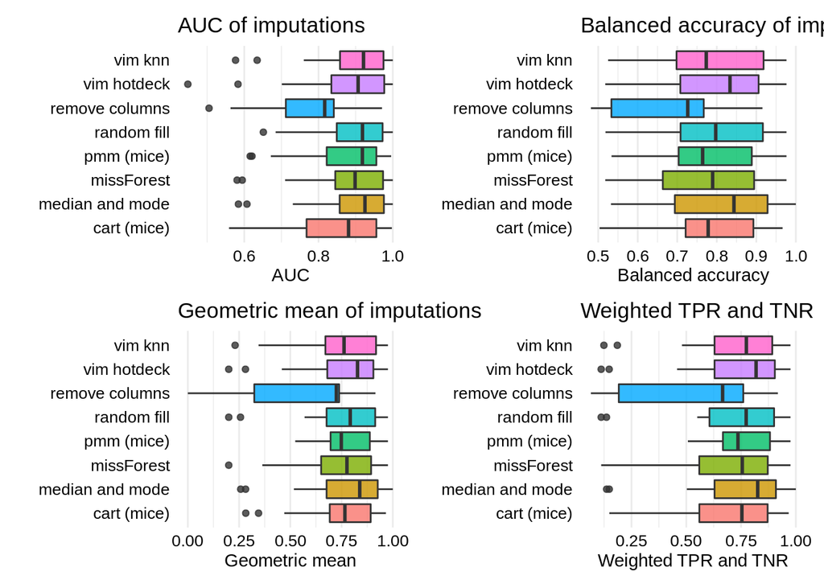

After analysing the plots there is significant difference between removing columns and the rest of imputations. Median and mode is one of best imputations here. High results are also achieved by VIM’s hotdeck imputation. Plots here have results from all models, and imputations but without those producing NA.

#### *Imputation time*

In imputation not only results matter. While having small dataset imputation time is not something worth considering. But when having tens or hundreds of thousands observations some more complex imputations might take really long time. In this case maximum samples in data is 5000 but diferences are already visible.

##### *Mean time*

Average results - time

| Imputation Name | Time |
| --- | --- |
| random fill | 0.0112452 |
| remove columns | 0.0155244 |
| median and mode | 0.0276497 |
| vim hotdeck | 0.2875616 |
| vim knn | 1.7117492 |
| missForest | 7.1055565 |
| pmm (mice) | 8.2962466 |
| cart (mice) | 14.2802260 |

##### *Distribution of time*

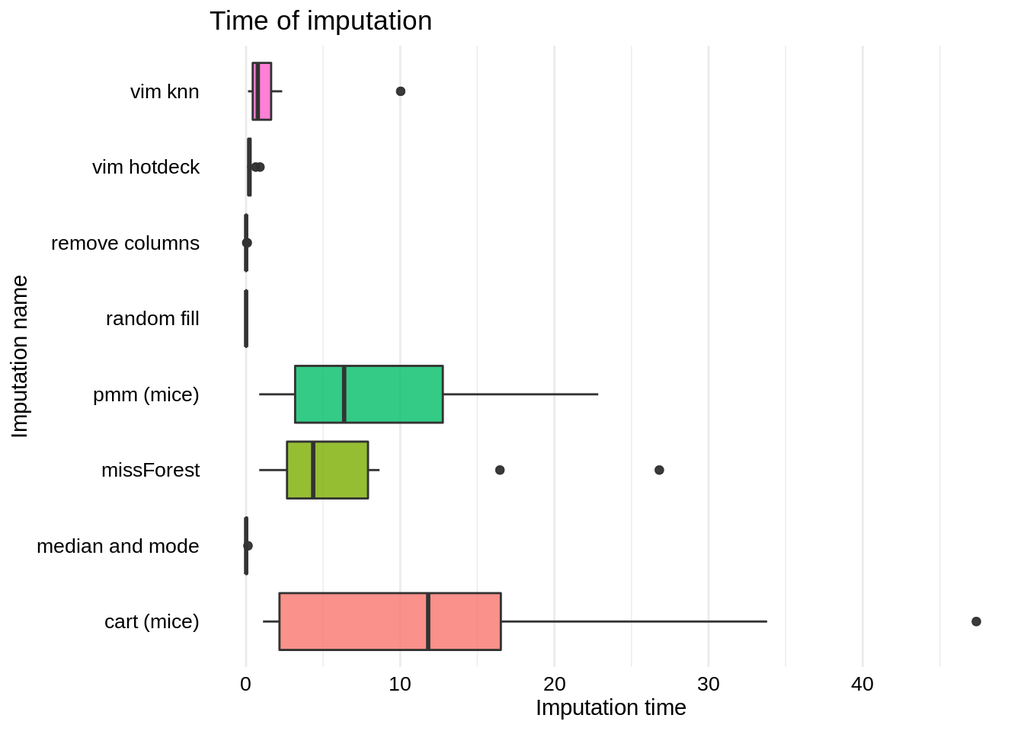

Imputation time shown in shape of boxplots. Clear distinction between mice and missForest packages functions which are significantly slower than other methods. On contrary here imputation time was taken into consideration even when NA’s were produced.

### Summary and conclusions

Our experiments have unexpected results - it turns out that using naive strategy of imputing with median and mode values resulted in models with the best performance. It might be due to the fact that many of our datasets were imbalanced and thus using more sophisticated metrics - such as Weighted TPR-TNR - might reflect model performence better. In that case, imputing with Fully Conditional Specification and predictive mean matching is the best option. Another reason of poor performance of more complex imputation methods might be the fact that we used default values of hyperparameters and some tuning may be required to show full potential of these methods. What was significant was big overhead that simple imputations had in terms of results achieved in time. While having big dataset with lots of missing values they might be the best solution. We might not ignore huge computational overhead that is the result of using complex computing methods. One have to think twice before using them and ask him or herself: why do I even bother? and use simple imputation instead.

[^1]: Anil S. Jadhav, A Novel Weighted TPR-TNR Measure to Assess Performance of the Classifiers, Expert Systems With Applications (2020), doi: https://doi.org/10.1016/j.eswa.2020.113391
[^2]: Daniel J. Stekhoven (2013). missForest: Nonparametric Missing Value Imputation using Random Forest. R package version 1.4. Stekhoven D. J., & Buehlmann, P. (2012). MissForest - non-parametric missing value imputation for mixed-type data. Bioinformatics, 28(1), 112-118.
[^3]: Kowarik A, Templ M (2016). “Imputation with the R Package VIM.” Journal of Statistical Software, 74(7), 1–16. doi: 10.18637/jss.v074.i07.
[^4]: van Buuren S, Groothuis-Oudshoorn K (2011). “mice: Multivariate Imputation by Chained Equations in R.” Journal of Statistical Software, 45(3), 1-67. url: https://www.jstatsoft.org/v45/i03/.